# Chapter 7: Exploratory Data Analysis

3. Install the ggstance package, and create a horizontal boxplot. How does this compare to using `coord_flip()`?

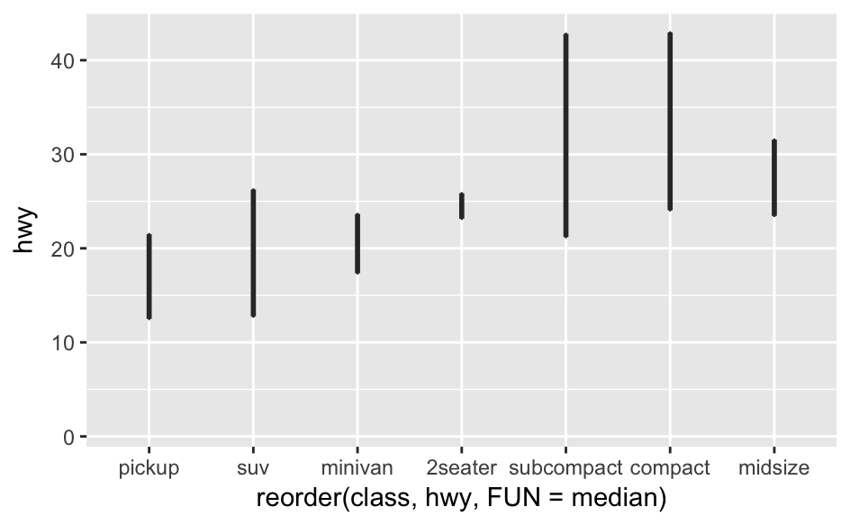

```r
library(ggstance)
ggplot(data = mpg) +
  geom_boxploth(mapping = aes(x = reorder(class, hwy, FUN = median), y = hwy))
```

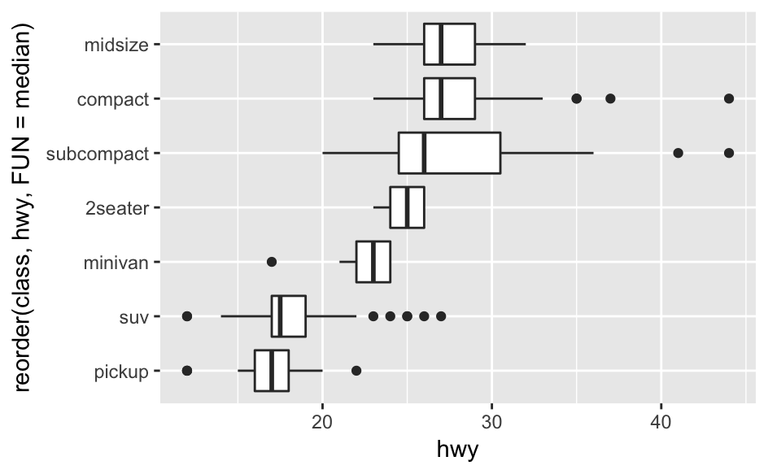

```r
ggplot(data = mpg) +
  geom_boxploth(mapping = aes(y = reorder(class, hwy, FUN = median), x = hwy))
```

**The key difference is that with ggstance you assign to the `y` axis the variable that would be assigned to the `x` axis before applying `coord_flip()`, and vice versa. In other words, ggstance maps directly onto the axes as they will appear in the horizontal plot.**

4. One problem with boxplots is that they were developed in an era of much smaller datasets and tend to display a prohibitively large number of “outlying values”. One approach to remedy this problem is the letter value plot. Install the lvplot package, and try using `geom_lv()` to display the distribution of price vs cut. What do you learn? How do you interpret the plots?

```r
library(lvplot)
ggplot(data = diamonds, mapping = aes(x = cut, y = price)) +
  geom_lv()
```

```
Error: GeomLv was built with an incompatible version of ggproto.
Please reinstall the package that provides this extension.
```

**There appears to be a package conflict that will need to be resolved.**

5. Compare and contrast `geom_violin()` with a facetted `geom_histogram()`, or a coloured `geom_freqpoly()`. What are the pros and cons of each method?

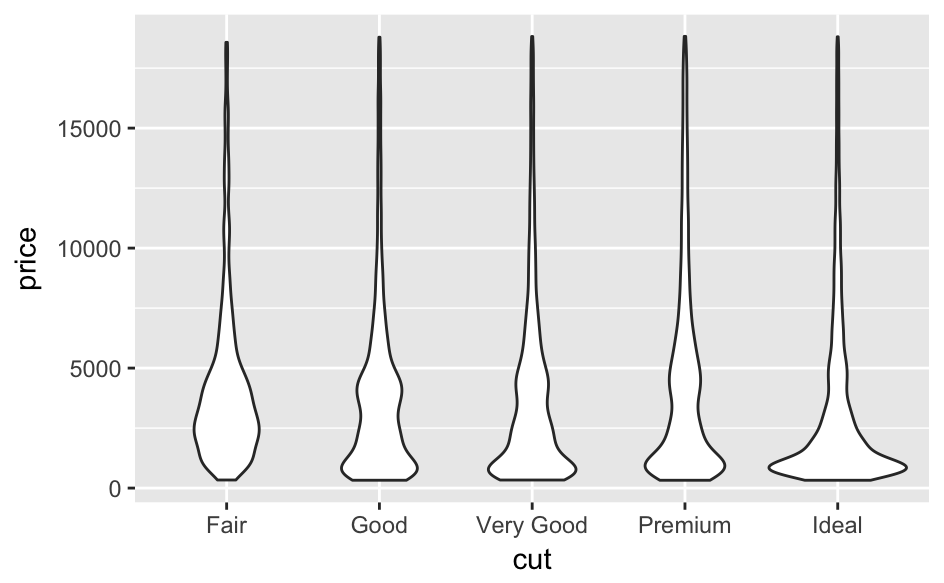

```r
ggplot(data = diamonds, mapping = aes(x = cut, y = price)) +
  geom_violin()
```

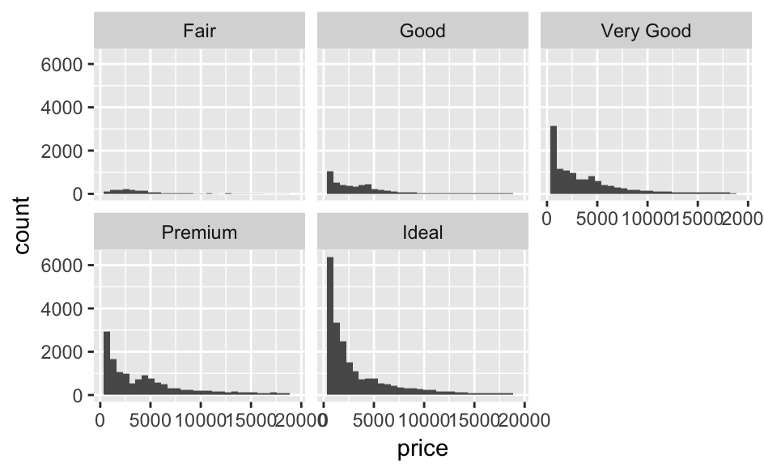

```r
ggplot(data = diamonds, mapping = aes(x = price)) +
  geom_histogram() +
  facet_wrap(~ cut)
```

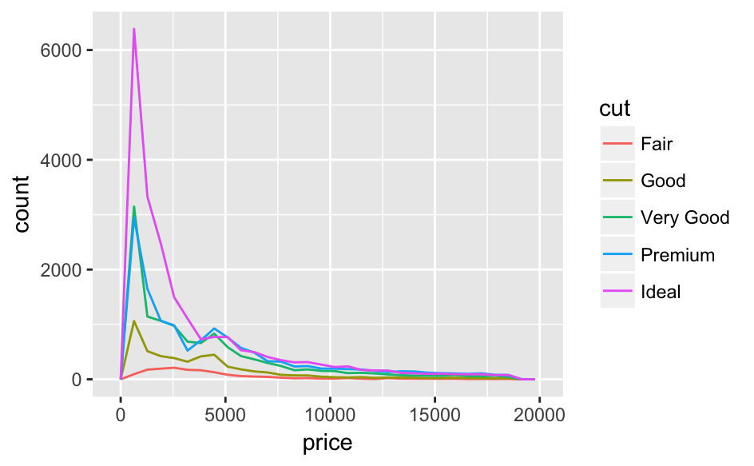

```r
ggplot(data = diamonds, mapping = aes(x = price)) +
  geom_freqpoly(mapping = aes(colour = cut))
```

6. If you have a small dataset, it’s sometimes useful to use `geom_jitter()` to see the relationship between a continuous and categorical variable. The ggbeeswarm package provides a number of methods similar to `geom_jitter()`. List them and briefly describe what each one does.

```r
library(ggbeeswarm)
?ggbeeswarm
```

**Look at `position_quasirandom()` and `position_beeswarm()`.**

## 7.5.2 Two categorical variables

### 7.5.2.1 Exercises

1. How could you rescale the count dataset above to more clearly show the distribution of cut within colour, or colour within cut?

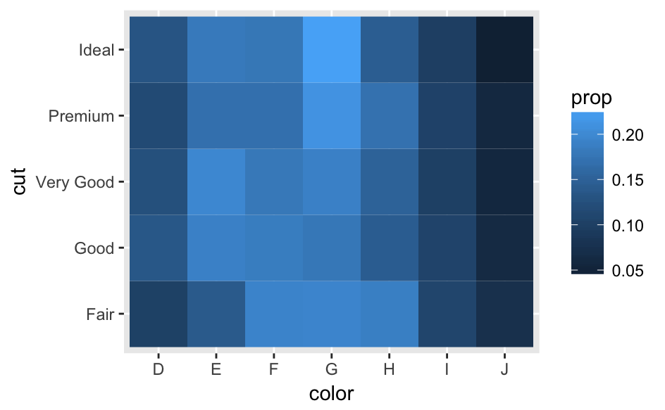

```r
diamonds %>%
  group_by(cut, color) %>%
  summarise(n = n()) %>%
  mutate(prop = n/sum(n)) %>%
  ggplot(mapping = aes(x = color, y = cut)) +
    geom_tile(mapping = aes(fill = prop))
```

**Calculating the proportion of colours within each cut rather than frequencies allows us to see the distribution of colours within each cut level more clearly.**

2. Use `geom_tile()` together with dplyr to explore how average flight delays vary by destination and month of year. What makes the plot difficult to read? How could you improve it?

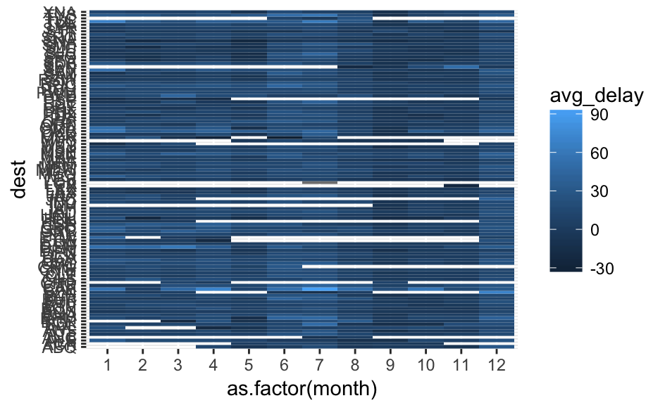

```r
library(nycflights13)
flights %>%
  group_by(dest, month) %>%
  summarise(avg_delay = mean(arr_delay, na.rm = TRUE)) %>%
  ggplot(mapping = aes(x = as.factor(month), y = dest)) +
    geom_tile(mapping = aes(fill = avg_delay))
```

**The number of destinations makes the y-axis overcrowded and even with the chart opened in a full-screen window it isn’t clearly readable.**

3. Why is it slightly better to use `aes(x = color, y = cut)` rather than `aes(x = cut, y = color)` in the example above?

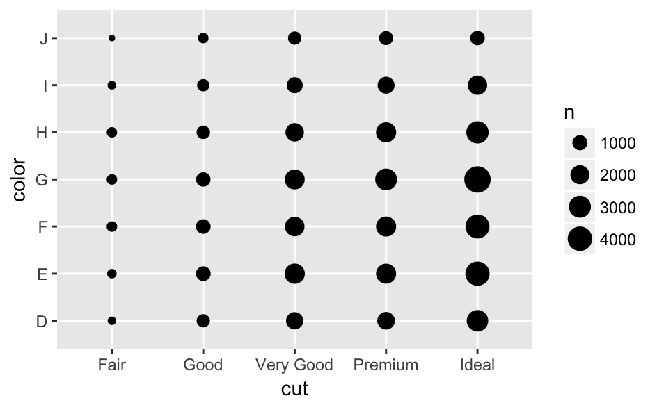

```r
ggplot(data = diamonds) +
  geom_count(mapping = aes(x = cut, y = color))
```

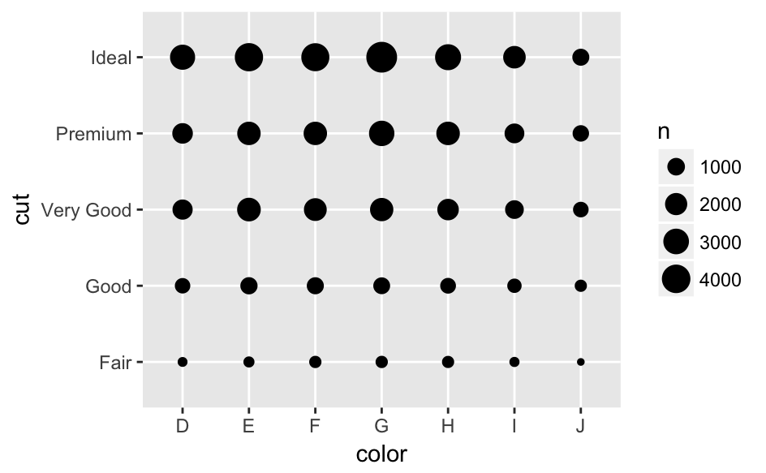

```r
ggplot(data = diamonds) +
  geom_count(mapping = aes(x = color, y = cut))
```

**Having colour on the x-axis narrows the width of the chart which seems to make comparison of points easier.**

## 7.5.3 Two continuous variables

### 7.5.3.1 Exercises

1. Instead of summarising the conditional distribution with a boxplot, you could use a frequency polygon. What do you need to consider when using `cut_width()` vs `cut_number()`? How does that impact a visualisation of the 2d distribution of carat and price?

```r
smaller <- diamonds %>%
  filter(carat < 3)
```

**I’ll need to come back to this.**

2. Visualise the distribution of carat, partitioned by price.

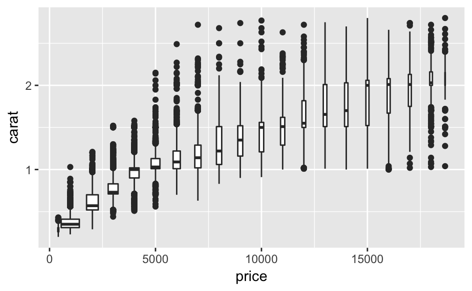

```r
ggplot(data = smaller, mapping = aes(x = price, y = carat)) +
  geom_boxplot(mapping = aes(group = cut_width(price, 1000)), varwidth = TRUE)
```

3. How does the price distribution of very large diamonds compare to small diamonds. Is it as you expect, or does it surprise you?

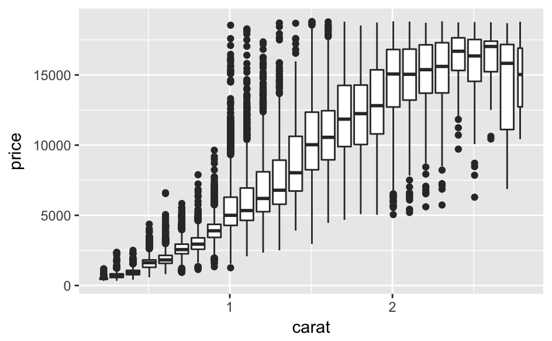

```r
ggplot(data = smaller, mapping = aes(x = carat, y = price)) +
  geom_boxplot(mapping = aes(group = cut_width(carat, 0.1)))
```

**The general trend that larger diamonds have higher average prices is a basic finding I would have expected, but the distributino boxplots show some other interesting patterns. The width of distributions is very narrow for the smallest diamonds so they are all very low price, but distributions become wider as the size increases, so it’s far from the case that all larger diamonds are higher-priced than some smaller diamonds. It’s around the 1 carat mark that the distribution becomes wider so that some outliers at that size have very high prices, but by the time you reach 2 carats those high prices have become the norm but there are now low-priced outliers instead.**

4. Combine two of the techniques you’ve learned to visualise the combined distribution of cut, carat, and price.

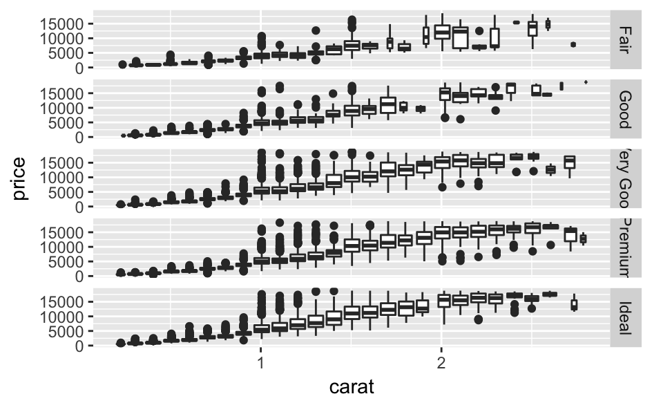

```r
ggplot(data = smaller, mapping = aes(x = carat, y = price)) +
  geom_boxplot(mapping = aes(group = cut_width(carat, 0.1))) +
  facet_grid(cut ~ .)
```

5. Two dimensional plots reveal outliers that are not visible in one dimensional plots. For example, some points in the plot below have an unusual combination of x and y values, which makes the points outliers even though their x and y values appear normal when examined separately.

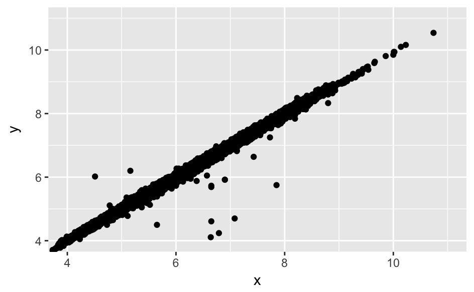

```r
ggplot(data = diamonds) +
  geom_point(mapping = aes(x = x, y = y)) +
  coord_cartesian(xlim = c(4, 11), ylim = c(4, 11))
```

Why is a scatterplot a better display than a binned plot for this case?

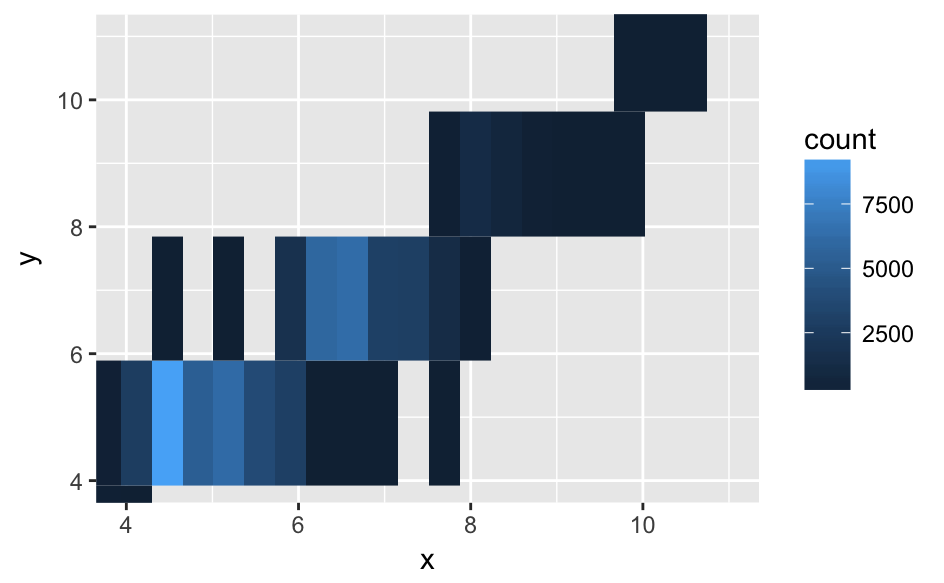

```r
ggplot(data = diamonds) +
  geom_bin2d(mapping = aes(x = x, y = y)) +
  coord_cartesian(xlim = c(4, 11), ylim = c(4, 11))
```

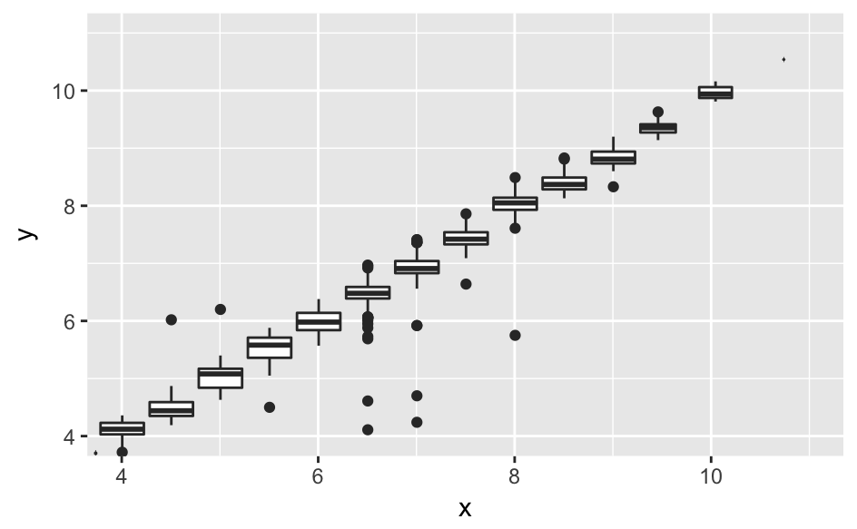

```r
ggplot(data = diamonds) +
  geom_boxplot(mapping = aes(x = x, y = y, group = cut_width(x, 0.5))) +
  coord_cartesian(xlim = c(4, 11), ylim = c(4, 11))
```

**The relationship is so strong and most points tightly clustered so they don’t break into useful subgroupings when binned.**